# Accelerometers Prediction

Kenia Sousa

9 Mar 2016

Using devices such as Jawbone Up, Nike FuelBand, and Fitbit it is now possible to collect a large amount of data about personal activity relatively inexpensively. These type of devices are part of the quantified self movement – a group of enthusiasts who take measurements about themselves regularly. One thing that people regularly do is quantify how much of a particular activity they do, but they rarely quantify how well they do it.

The data used is from accelerometers on the belt, forearm, arm, and dumbell of 6 participants. They were asked to perform barbell lifts correctly and incorrectly in 5 different ways. The goal of this project is to predict the manner in which they did the exercise.

More information is available from the website here: http://groupware.les.inf.puc-rio.br/har (see the section on the Weight Lifting Exercise Dataset).

## Load the Data

The data are in the GitHub project and available in the links listed as follows:

The training data: https://d396qusza40orc.cloudfront.net/predmachlearn/pml-training.csv

The test data: https://d396qusza40orc.cloudfront.net/predmachlearn/pml-testing.csv

The first step is to load the data:

```r
require(caret)
training <- read.csv("pml-training.csv", sep = ",", na.strings="NA")
testingAcc <- read.csv("pml-testing.csv", sep = ",", na.strings="NA")
```

# Explore the data

There are 19,622 observations and 160 variables in the training set.

There are 20 observations and 160 variables in the testing set.

```r
dim(training)
```

```
## [1] 19622   160
```

```r
dim(testingAcc)
```

```
## [1]  20 160
```

We know that the variable “classe” represents the manner in which the participants did the exercise, which will be the outcome.

Six young health participants were asked to perform one set of 10 repetitions of the Unilateral Dumbbell Biceps Curl in five different fashions:

- exactly according to the specification (Class A),
- throwing the elbows to the front (Class B),
- lifting the dumbbell only halfway (Class C),
- lowering the dumbbell only halfway (Class D) and
- throwing the hips to the front (Class E).

Read more at: http://groupware.les.inf.puc-rio.br/har#ixzz42rOddXrC

So, we explore this variable “classe” and look at the distribution of values per classe in the training set.

```r
levels(training$classe)
```

```
## [1] "A" "B" "C" "D" "E"
```

```r
table(training$classe)
```

```
##
##    A    B    C    D    E
## 5580 3797 3422 3216 3607
```

Looking at the structure of the data, it is strange to see that there are factor variables with several levels, some with 400 levels. From several tests done, there was even an error saying that Random Forest can not handle categorical predictors with more than 53 categories. And looking at the test set, the same variables are numeric.

```r
str(training)
```

```
## 'data.frame':    19622 obs. of  160 variables:
##  $ X                       : int  1 2 3 4 5 6 7 8 9 10 ...
##  $ user_name               : Factor w/ 6 levels "adelmo","carlitos",..: 2 2 2 2 2 2 2 2 2 2 ...
##  $ raw_timestamp_part_1    : int  1323084231 1323084231 1323084231 1323084232 1323084232 1323084232 1323084232 1323084232 1323084232 1323084232 ...
##  $ raw_timestamp_part_2    : int  788290 808298 820366 120339 196328 304277 368296 440390 484323 484434 ...
##  $ cvtd_timestamp          : Factor w/ 20 levels "02/12/2011 13:32",..: 9 9 9 9 9 9 9 9 9 9 ...
##  $ new_window              : Factor w/ 2 levels "no","yes": 1 1 1 1 1 1 1 1 1 1 ...
##  $ num_window              : int  11 11 11 12 12 12 12 12 12 12 ...
##  $ roll_belt               : num  1.41 1.41 1.42 1.48 1.48 1.45 1.42 1.42 1.43 1.45 ...
##  $ pitch_belt              : num  8.07 8.07 8.07 8.05 8.07 8.06 8.09 8.13 8.16 8.17 ...
##  $ yaw_belt                : num  -94.4 -94.4 -94.4 -94.4 -94.4 -94.4 -94.4 -94.4 -94.4 -94.4 ...
##  $ total_accel_belt        : int  3 3 3 3 3 3 3 3 3 3 ...
##  $ kurtosis_roll_belt      : Factor w/ 397 levels "","-0.016850",..: 1 1 1 1 1 1 1 1 1 1 ...
##  $ kurtosis_picth_belt     : Factor w/ 317 levels "","-0.021887",..: 1 1 1 1 1 1 1 1 1 1 ...
##  $ kurtosis_yaw_belt       : Factor w/ 2 levels "","#DIV/0!": 1 1 1 1 1 1 1 1 1 1 ...
```

[output cut: 86 more lines]

```r
str(testingAcc)
```

```
## 'data.frame':    20 obs. of  160 variables:
##  $ X                       : int  1 2 3 4 5 6 7 8 9 10 ...
##  $ user_name               : Factor w/ 6 levels "adelmo","carlitos",..: 6 5 5 1 4 5 5 5 2 3 ...
##  $ raw_timestamp_part_1    : int  1323095002 1322673067 1322673075 1322832789 1322489635 1322673149 1322673128 1322673076 1323084240 1322837822 ...
##  $ raw_timestamp_part_2    : int  868349 778725 342967 560311 814776 510661 766645 54671 916313 384285 ...
##  $ cvtd_timestamp          : Factor w/ 11 levels "02/12/2011 13:33",..: 5 10 10 1 6 11 11 10 3 2 ...
##  $ new_window              : Factor w/ 1 level "no": 1 1 1 1 1 1 1 1 1 1 ...
##  $ num_window              : int  74 431 439 194 235 504 485 440 323 664 ...
##  $ roll_belt               : num  123 1.02 0.87 125 1.35 -5.92 1.2 0.43 0.93 114 ...
##  $ pitch_belt              : num  27 4.87 1.82 -41.6 3.33 1.59 4.44 4.15 6.72 22.4 ...
##  $ yaw_belt                : num  -4.75 -88.9 -88.5 162 -88.6 -87.7 -87.3 -88.5 -93.7 -13.1 ...
##  $ total_accel_belt        : int  20 4 5 17 3 4 4 4 4 18 ...
##  $ kurtosis_roll_belt      : logi  NA NA NA NA NA NA ...
##  $ kurtosis_picth_belt     : logi  NA NA NA NA NA NA ...
##  $ kurtosis_yaw_belt       : logi  NA NA NA NA NA NA ...
```

[output cut: 86 more lines]

We can also notice that there are a lot of missing values.

At first, I had left the missing values and trained the models, but different errors and warnings appeared.

I used two pre-processing methods: a)The method = “nzv” identifies numeric predictor columns by applying nearZeroVar with the default parameters to exclude “near zero-variance” predictors. The method “nzv” was added because there were warnings indicating several variables have no variation. b)The method=“knnImpute” does imputation using k-nearest neighbors. For each record, identify missing features. For each missing feature find the k nearest neighbors which have that feature. Impute the missing value using the imputation function on the k-length vector of values found from the neighbors. I also used the argument na.action = na.exclude, which determines that the missing values will appear with value NA. Since I did the training keeping the missing values, I also maintained them in the predictions by using na.action=NULL. http://stackoverflow.com/questions/34324930/predicting-new-data-with-nas-with-gbm-in-r

Despite these methods, the predictions in the validation set were still wrong, with accuracy metric missing, for instance. So, after studying and several tests with different arguments in train() for the training set and predict() in the validation set, I looked closely to the data and decided to process them.

Knowing that training and test must be processed in the same way, I first removed the missing values from both data sets:

If the count of NAs in a column is equal to zero, meaning, without NAs, then I keep it in the data set.

After removing the variables with missing values and keeping only the variables related to the data from accelerometers on the belt, forearm, arm, and dumbell, the factor variables with many levels are removed. Good news!

Pre-processing on the testing data set:

```r
testingAcc.clean <-testingAcc[,8:160]
testingAcc.clean <- testingAcc.clean[,colSums(is.na(testingAcc.clean))==0]
dim(testingAcc.clean)
```

```
## [1] 20 53
```

```r
str(testingAcc.clean)
```

```
## 'data.frame':    20 obs. of  53 variables:
##  $ roll_belt           : num  123 1.02 0.87 125 1.35 -5.92 1.2 0.43 0.93 114 ...
##  $ pitch_belt          : num  27 4.87 1.82 -41.6 3.33 1.59 4.44 4.15 6.72 22.4 ...
##  $ yaw_belt            : num  -4.75 -88.9 -88.5 162 -88.6 -87.7 -87.3 -88.5 -93.7 -13.1 ...
##  $ total_accel_belt    : int  20 4 5 17 3 4 4 4 4 18 ...
##  $ gyros_belt_x        : num  -0.5 -0.06 0.05 0.11 0.03 0.1 -0.06 -0.18 0.1 0.14 ...
##  $ gyros_belt_y        : num  -0.02 -0.02 0.02 0.11 0.02 0.05 0 -0.02 0 0.11 ...
##  $ gyros_belt_z        : num  -0.46 -0.07 0.03 -0.16 0 -0.13 0 -0.03 -0.02 -0.16 ...
##  $ accel_belt_x        : int  -38 -13 1 46 -8 -11 -14 -10 -15 -25 ...
##  $ accel_belt_y        : int  69 11 -1 45 4 -16 2 -2 1 63 ...
##  $ accel_belt_z        : int  -179 39 49 -156 27 38 35 42 32 -158 ...
##  $ magnet_belt_x       : int  -13 43 29 169 33 31 50 39 -6 10 ...
##  $ magnet_belt_y       : int  581 636 631 608 566 638 622 635 600 601 ...
##  $ magnet_belt_z       : int  -382 -309 -312 -304 -418 -291 -315 -305 -302 -330 ...
##  $ roll_arm            : num  40.7 0 0 -109 76.1 0 0 0 -137 -82.4 ...
```

[output cut: 39 more lines]

Pre-processing on the training data set:

```r
training.clean <-training[,8:160]
training.clean <- training.clean[,colSums(is.na(testingAcc[,8:160]))==0]
dim(training.clean)
```

```
## [1] 19622    53
```

```r
str(training.clean)
```

```
## 'data.frame':    19622 obs. of  53 variables:
##  $ roll_belt           : num  1.41 1.41 1.42 1.48 1.48 1.45 1.42 1.42 1.43 1.45 ...
##  $ pitch_belt          : num  8.07 8.07 8.07 8.05 8.07 8.06 8.09 8.13 8.16 8.17 ...
##  $ yaw_belt            : num  -94.4 -94.4 -94.4 -94.4 -94.4 -94.4 -94.4 -94.4 -94.4 -94.4 ...
##  $ total_accel_belt    : int  3 3 3 3 3 3 3 3 3 3 ...
##  $ gyros_belt_x        : num  0 0.02 0 0.02 0.02 0.02 0.02 0.02 0.02 0.03 ...
##  $ gyros_belt_y        : num  0 0 0 0 0.02 0 0 0 0 0 ...
##  $ gyros_belt_z        : num  -0.02 -0.02 -0.02 -0.03 -0.02 -0.02 -0.02 -0.02 -0.02 0 ...
##  $ accel_belt_x        : int  -21 -22 -20 -22 -21 -21 -22 -22 -20 -21 ...
##  $ accel_belt_y        : int  4 4 5 3 2 4 3 4 2 4 ...
##  $ accel_belt_z        : int  22 22 23 21 24 21 21 21 24 22 ...
##  $ magnet_belt_x       : int  -3 -7 -2 -6 -6 0 -4 -2 1 -3 ...
##  $ magnet_belt_y       : int  599 608 600 604 600 603 599 603 602 609 ...
##  $ magnet_belt_z       : int  -313 -311 -305 -310 -302 -312 -311 -313 -312 -308 ...
##  $ roll_arm            : num  -128 -128 -128 -128 -128 -128 -128 -128 -128 -128 ...
```

[output cut: 39 more lines]

```r
table(training.clean$classe)
```

```
##
##    A    B    C    D    E
## 5580 3797 3422 3216 3607
```

Now, organize the data sets in training, validation and testing sets:

There are 13,737 observations and 53 variables in the training set.

There are 5,885 observations and 53 variables in the validation set.

There are 20 observations and 53 variables in the testing set.

```r
inBuild <- createDataPartition(y=training.clean$classe, p=0.7,list=FALSE)
validationAcc <- training.clean[-inBuild,]
dim(validationAcc)
```

```
## [1] 5885   53
```

```r
trainingAcc <- training.clean[inBuild,]
dim(trainingAcc)
```

```
## [1] 13737    53
```

```r
summary(trainingAcc)
```

```
##    roll_belt        pitch_belt         yaw_belt       total_accel_belt
##  Min.   :-28.90   Min.   :-54.900   Min.   :-180.00   Min.   : 0.00
##  1st Qu.:  1.09   1st Qu.:  1.800   1st Qu.: -88.30   1st Qu.: 3.00
##  Median :113.00   Median :  5.290   Median : -13.40   Median :17.00
##  Mean   : 64.17   Mean   :  0.441   Mean   : -11.71   Mean   :11.29
##  3rd Qu.:123.00   3rd Qu.: 15.200   3rd Qu.:   6.84   3rd Qu.:18.00
##  Max.   :162.00   Max.   : 60.300   Max.   : 179.00   Max.   :28.00
##   gyros_belt_x        gyros_belt_y       gyros_belt_z
##  Min.   :-1.040000   Min.   :-0.64000   Min.   :-1.3000
##  1st Qu.:-0.030000   1st Qu.: 0.00000   1st Qu.:-0.2000
##  Median : 0.030000   Median : 0.02000   Median :-0.1000
##  Mean   :-0.006079   Mean   : 0.03918   Mean   :-0.1306
##  3rd Qu.: 0.110000   3rd Qu.: 0.11000   3rd Qu.:-0.0200
##  Max.   : 2.220000   Max.   : 0.64000   Max.   : 1.6200
##   accel_belt_x       accel_belt_y    accel_belt_z     magnet_belt_x
##  Min.   :-120.000   Min.   :-69.0   Min.   :-266.00   Min.   :-52.00
##  1st Qu.: -21.000   1st Qu.:  3.0   1st Qu.:-162.00   1st Qu.:  9.00
##  Median : -15.000   Median : 34.0   Median :-152.00   Median : 35.00
##  Mean   :  -5.792   Mean   : 30.1   Mean   : -72.23   Mean   : 55.32
##  3rd Qu.:  -5.000   3rd Qu.: 61.0   3rd Qu.:  28.00   3rd Qu.: 59.00
##  Max.   :  83.000   Max.   :164.0   Max.   : 105.00   Max.   :481.00
##  magnet_belt_y   magnet_belt_z       roll_arm         pitch_arm
##  Min.   :354.0   Min.   :-621.0   Min.   :-180.00   Min.   :-88.800
##  1st Qu.:581.0   1st Qu.:-375.0   1st Qu.: -31.60   1st Qu.:-25.600
##  Median :601.0   Median :-319.0   Median :   0.00   Median :  0.000
##  Mean   :593.9   Mean   :-345.1   Mean   :  17.75   Mean   : -4.551
##  3rd Qu.:610.0   3rd Qu.:-306.0   3rd Qu.:  77.20   3rd Qu.: 11.100
##  Max.   :673.0   Max.   : 293.0   Max.   : 179.00   Max.   : 88.500
##     yaw_arm          total_accel_arm  gyros_arm_x        gyros_arm_y
##  Min.   :-180.0000   Min.   : 1.00   Min.   :-6.37000   Min.   :-3.4400
##  1st Qu.: -42.2000   1st Qu.:17.00   1st Qu.:-1.30000   1st Qu.:-0.8000
##  Median :   0.0000   Median :27.00   Median : 0.08000   Median :-0.2400
##  Mean   :  -0.1996   Mean   :25.47   Mean   : 0.05538   Mean   :-0.2605
##  3rd Qu.:  46.2000   3rd Qu.:33.00   3rd Qu.: 1.57000   3rd Qu.: 0.1400
##  Max.   : 180.0000   Max.   :66.00   Max.   : 4.87000   Max.   : 2.8100
##   gyros_arm_z       accel_arm_x       accel_arm_y       accel_arm_z
##  Min.   :-2.3300   Min.   :-404.00   Min.   :-318.00   Min.   :-636.00
##  1st Qu.:-0.0700   1st Qu.:-241.00   1st Qu.: -54.00   1st Qu.:-143.00
##  Median : 0.2300   Median : -44.00   Median :  14.00   Median : -47.00
##  Mean   : 0.2717   Mean   : -60.16   Mean   :  32.95   Mean   : -70.85
```

[output cut: 50 more lines]

```
##  Max.   :311.00000   Max.   :231.0000   Max.   : 477.00   Max.   : 923.0
##  accel_forearm_z  magnet_forearm_x  magnet_forearm_y magnet_forearm_z
##  Min.   :-446.0   Min.   :-1280.0   Min.   :-896.0   Min.   :-973.0
##  1st Qu.:-182.0   1st Qu.: -617.0   1st Qu.:   9.0   1st Qu.: 196.0
##  Median : -41.0   Median : -377.0   Median : 594.0   Median : 510.0
##  Mean   : -55.7   Mean   : -313.2   Mean   : 383.1   Mean   : 393.4
##  3rd Qu.:  25.0   3rd Qu.:  -73.0   3rd Qu.: 737.0   3rd Qu.: 652.0
##  Max.   : 291.0   Max.   :  672.0   Max.   :1480.0   Max.   :1090.0
##  classe
##  A:3906
##  B:2658
##  C:2396
##  D:2252
##  E:2525
##
```

```r
testingAccFinal <- testingAcc.clean
dim(testingAccFinal)
```

```
## [1] 20 53
```

Here, the featurePlot depicts the association between some features that represent the total of measures from the accelerometers. We can see two separate groups in terms of the outcome for the feature “total_accel_belt”.

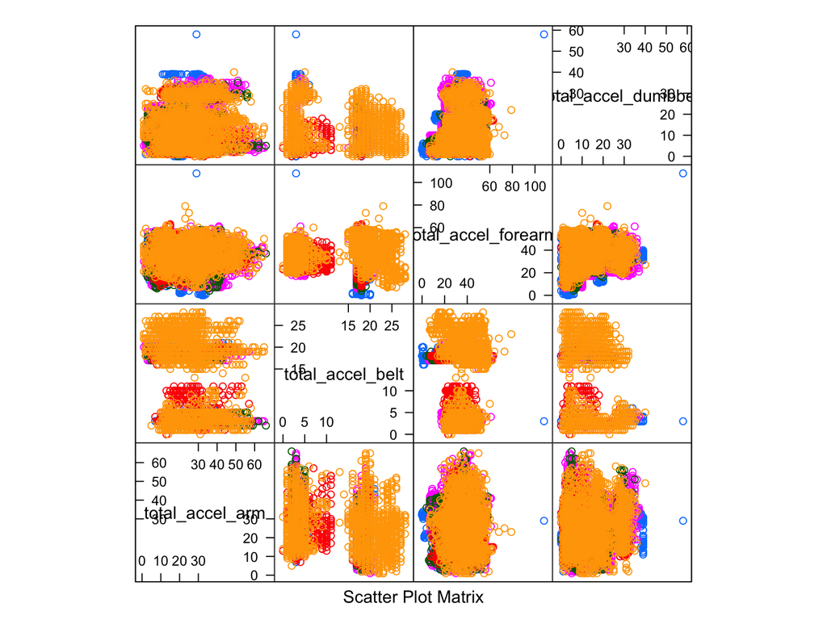

```r
featurePlot(x = trainingAcc[,c("total_accel_arm","total_accel_belt","total_accel_forearm","total_accel_dumbbell")], y = trainingAcc$classe, plot="pairs")
```

## How built the model

Set the seed for each model for reproducibility.

Then, predict the manner in which the participants did the exercise with each model using the “classe” variable in the validation set.

### Predicting with trees

Predicting with trees iteratively splits the variables into groups.

#### Create the model

```r
require(rpart)
#install.packages('e1071', dependencies=TRUE)
set.seed(333)
mod.rpart <- train(classe ~ .,data=trainingAcc, method="rpart")
mod.rpart
```

```
## CART
##
## 13737 samples
##    52 predictor
##     5 classes: 'A', 'B', 'C', 'D', 'E'
##
## No pre-processing
## Resampling: Bootstrapped (25 reps)
## Summary of sample sizes: 13737, 13737, 13737, 13737, 13737, 13737, ...
## Resampling results across tuning parameters:
##
##   cp          Accuracy   Kappa       Accuracy SD  Kappa SD
##   0.03143119  0.5131888  0.36731154  0.04423423   0.06952675
##   0.06021768  0.4082525  0.19692416  0.06274090   0.10477948
##   0.11128064  0.3113355  0.04230182  0.03886198   0.05758249
##
## Accuracy was used to select the optimal model using  the largest value.
## The final value used for the model was cp = 0.03143119.
```

```r
mod.rpart$finalModel
```

```
## n= 13737
##
## node), split, n, loss, yval, (yprob)
##       * denotes terminal node
##
##  1) root 13737 9831 A (0.28 0.19 0.17 0.16 0.18)
##    2) roll_belt< 130.5 12627 8729 A (0.31 0.21 0.19 0.18 0.11)
##      4) pitch_forearm< -33.35 1127   11 A (0.99 0.0098 0 0 0) *
##      5) pitch_forearm>=-33.35 11500 8718 A (0.24 0.23 0.21 0.2 0.12)
##       10) magnet_dumbbell_y< 439.5 9730 7000 A (0.28 0.18 0.24 0.19 0.11)
##         20) roll_forearm< 122.5 6019 3582 A (0.4 0.18 0.19 0.17 0.062) *
##         21) roll_forearm>=122.5 3711 2504 C (0.079 0.18 0.33 0.23 0.19) *
##       11) magnet_dumbbell_y>=439.5 1770  856 B (0.029 0.52 0.042 0.22 0.19) *
##    3) roll_belt>=130.5 1110    8 E (0.0072 0 0 0 0.99) *
```

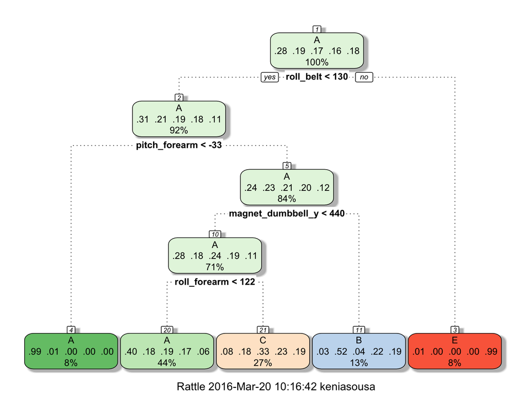

```r
require(rattle)
require(rpart.plot)
fancyRpartPlot(mod.rpart$finalModel)
```

#### Predict the model

```r
pred.rpart <- predict(mod.rpart,validationAcc)
table(pred.rpart,validationAcc$classe)
```

```
##
## pred.rpart    A    B    C    D    E
##          A 1527  492  471  412  151
##          B   29  372   34  180  144
##          C  112  275  521  372  258
##          D    0    0    0    0    0
##          E    6    0    0    0  529
```

```r
confusionMatrix(pred.rpart,validationAcc$classe)
```

```
## Confusion Matrix and Statistics
##
##           Reference
## Prediction    A    B    C    D    E
##          A 1527  492  471  412  151
##          B   29  372   34  180  144
##          C  112  275  521  372  258
##          D    0    0    0    0    0
##          E    6    0    0    0  529
##
## Overall Statistics
##
##                Accuracy : 0.5011
##                  95% CI : (0.4882, 0.514)
##     No Information Rate : 0.2845
##     P-Value [Acc > NIR] : < 2.2e-16
##
##                   Kappa : 0.348
##  Mcnemar's Test P-Value : NA
##
## Statistics by Class:
##
##                      Class: A Class: B Class: C Class: D Class: E
## Sensitivity            0.9122  0.32660  0.50780   0.0000  0.48891
## Specificity            0.6376  0.91846  0.79070   1.0000  0.99875
## Pos Pred Value         0.5002  0.49012  0.33875      NaN  0.98879
## Neg Pred Value         0.9481  0.85037  0.88383   0.8362  0.89664
## Prevalence             0.2845  0.19354  0.17434   0.1638  0.18386
## Detection Rate         0.2595  0.06321  0.08853   0.0000  0.08989
## Detection Prevalence   0.5188  0.12897  0.26134   0.0000  0.09091
## Balanced Accuracy      0.7749  0.62253  0.64925   0.5000  0.74383
```

### Random Forest

Random Forest is run using cross validation with 3 folds.

The training set is divided in 3 folds to create cross validation. Three different combinations of these 3 folds are tried, where 2 folds are used as training set and 1 fold is used as a testing set. Then, the errors are averaged to pick a prediction model with the lowest error rate. This is a way to verify how accurate the model is before using the test data.

#### Create the model

```r
require(randomForest)
set.seed(333)
mod.rf3 <- train(classe ~.,method = "rf", data=trainingAcc, trControl=trainControl(method="cv",number=3))
mod.rf3$finalModel
```

```
##
## Call:
##  randomForest(x = x, y = y, mtry = param$mtry)
##                Type of random forest: classification
##                      Number of trees: 500
## No. of variables tried at each split: 27
##
##         OOB estimate of  error rate: 0.69%
## Confusion matrix:
##      A    B    C    D    E class.error
## A 3902    3    0    0    1 0.001024066
## B   21 2629    7    1    0 0.010910459
## C    0   10 2373   13    0 0.009599332
## D    0    1   25 2223    3 0.012877442
## E    0    1    4    5 2515 0.003960396
```

```r
mod.rf3
```

```
## Random Forest
##
## 13737 samples
##    52 predictor
##     5 classes: 'A', 'B', 'C', 'D', 'E'
##
## No pre-processing
## Resampling: Cross-Validated (3 fold)
## Summary of sample sizes: 9158, 9157, 9159
## Resampling results across tuning parameters:
##
##   mtry  Accuracy   Kappa      Accuracy SD   Kappa SD
##    2    0.9876247  0.9843448  0.0007655088  0.0009644558
##   27    0.9891536  0.9862790  0.0017629302  0.0022295370
##   52    0.9835481  0.9791861  0.0012790838  0.0016125566
##
## Accuracy was used to select the optimal model using  the largest value.
## The final value used for the model was mtry = 27.
```

#### Predict the model

```r
pred.rf3 <- predict(mod.rf3,validationAcc)
table(pred.rf3,validationAcc$classe)
```

```
##
## pred.rf3    A    B    C    D    E
##        A 1672   11    0    0    0
##        B    1 1127    6    0    1
##        C    0    1 1012    8    1
##        D    0    0    8  954    1
##        E    1    0    0    2 1079
```

```r
confusionMatrix(pred.rf3,validationAcc$classe)
```

```
## Confusion Matrix and Statistics
##
##           Reference
## Prediction    A    B    C    D    E
##          A 1672   11    0    0    0
##          B    1 1127    6    0    1
##          C    0    1 1012    8    1
##          D    0    0    8  954    1
##          E    1    0    0    2 1079
##
## Overall Statistics
##
##                Accuracy : 0.993
##                  95% CI : (0.9906, 0.995)
##     No Information Rate : 0.2845
##     P-Value [Acc > NIR] : < 2.2e-16
##
##                   Kappa : 0.9912
##  Mcnemar's Test P-Value : NA
##
## Statistics by Class:
##
##                      Class: A Class: B Class: C Class: D Class: E
## Sensitivity            0.9988   0.9895   0.9864   0.9896   0.9972
## Specificity            0.9974   0.9983   0.9979   0.9982   0.9994
## Pos Pred Value         0.9935   0.9930   0.9902   0.9907   0.9972
## Neg Pred Value         0.9995   0.9975   0.9971   0.9980   0.9994
## Prevalence             0.2845   0.1935   0.1743   0.1638   0.1839
## Detection Rate         0.2841   0.1915   0.1720   0.1621   0.1833
## Detection Prevalence   0.2860   0.1929   0.1737   0.1636   0.1839
## Balanced Accuracy      0.9981   0.9939   0.9921   0.9939   0.9983
```

### Boosting

Boosting with trees is run using cross validation with 3 folds.

#### Create the model

```r
set.seed(333)
mod.gbm <- train(classe ~.,method = "gbm", data=trainingAcc, verbose=FALSE, trControl=trainControl(method="cv",number=3))
mod.gbm$finalModel
```

```
## A gradient boosted model with multinomial loss function.
## 150 iterations were performed.
## There were 52 predictors of which 44 had non-zero influence.
```

```r
mod.gbm
```

```
## Stochastic Gradient Boosting
##
## 13737 samples
##    52 predictor
##     5 classes: 'A', 'B', 'C', 'D', 'E'
##
## No pre-processing
## Resampling: Cross-Validated (3 fold)
## Summary of sample sizes: 9158, 9157, 9159
## Resampling results across tuning parameters:
##
##   interaction.depth  n.trees  Accuracy   Kappa      Accuracy SD
##   1                   50      0.7513283  0.6847877  0.001693377
##   1                  100      0.8222317  0.7751048  0.005446375
##   1                  150      0.8512039  0.8117203  0.007315590
##   2                   50      0.8560816  0.8176905  0.003814763
##   2                  100      0.9055102  0.8804398  0.003201128
##   2                  150      0.9288779  0.9100134  0.002827777
##   3                   50      0.8929891  0.8645388  0.005127625
##   3                  100      0.9392149  0.9230934  0.003677775
##   3                  150      0.9582151  0.9471404  0.002271014
##   Kappa SD
##   0.001908900
##   0.006801316
##   0.009235719
##   0.004845686
##   0.004024646
##   0.003582158
##   0.006459264
##   0.004621301
##   0.002843044
##
## Tuning parameter 'shrinkage' was held constant at a value of 0.1
##
## Tuning parameter 'n.minobsinnode' was held constant at a value of 10
## Accuracy was used to select the optimal model using  the largest value.
## The final values used for the model were n.trees = 150,
##  interaction.depth = 3, shrinkage = 0.1 and n.minobsinnode = 10.
```

#### Predict the model

```r
pred.gbm <- predict(mod.gbm,validationAcc)
confusionMatrix(pred.gbm,validationAcc$classe)
```

```
## Confusion Matrix and Statistics
##
##           Reference
## Prediction    A    B    C    D    E
##          A 1645   32    0    1    1
##          B   19 1075   30    3    9
##          C    6   31  981   31    9
##          D    2    0   14  923    8
##          E    2    1    1    6 1055
##
## Overall Statistics
##
##                Accuracy : 0.965
##                  95% CI : (0.96, 0.9695)
##     No Information Rate : 0.2845
##     P-Value [Acc > NIR] : < 2.2e-16
##
##                   Kappa : 0.9557
##  Mcnemar's Test P-Value : 0.0003298
##
## Statistics by Class:
##
##                      Class: A Class: B Class: C Class: D Class: E
## Sensitivity            0.9827   0.9438   0.9561   0.9575   0.9750
## Specificity            0.9919   0.9871   0.9842   0.9951   0.9979
## Pos Pred Value         0.9797   0.9463   0.9272   0.9747   0.9906
## Neg Pred Value         0.9931   0.9865   0.9907   0.9917   0.9944
## Prevalence             0.2845   0.1935   0.1743   0.1638   0.1839
## Detection Rate         0.2795   0.1827   0.1667   0.1568   0.1793
## Detection Prevalence   0.2853   0.1930   0.1798   0.1609   0.1810
## Balanced Accuracy      0.9873   0.9655   0.9701   0.9763   0.9865
```

### Bagging

Bagging is run using default settings of parameters.

#### Create the model

```r
set.seed(333)
mod.treebag2 <- train(classe ~.,method = "treebag", data=trainingAcc)
mod.treebag2$finalModel
```

```
##
## Bagging classification trees with 25 bootstrap replications
```

```r
mod.treebag2
```

```
## Bagged CART
##
## 13737 samples
##    52 predictor
##     5 classes: 'A', 'B', 'C', 'D', 'E'
##
## No pre-processing
## Resampling: Bootstrapped (25 reps)
## Summary of sample sizes: 13737, 13737, 13737, 13737, 13737, 13737, ...
## Resampling results
##
##   Accuracy   Kappa      Accuracy SD  Kappa SD
##   0.9778948  0.9720375  0.004887264  0.006186982
##
##
```

#### Predict the model

```r
require(RANN)
pred.treebag2 <- predict(mod.treebag2,validationAcc)
confusionMatrix(pred.treebag2,validationAcc$classe)
```

```
## Confusion Matrix and Statistics
##
##           Reference
## Prediction    A    B    C    D    E
##          A 1664   12    1    2    0
##          B    4 1120    8    3    3
##          C    3    6 1010   13    4
##          D    2    1    7  944    3
##          E    1    0    0    2 1072
##
## Overall Statistics
##
##                Accuracy : 0.9873
##                  95% CI : (0.9841, 0.99)
##     No Information Rate : 0.2845
##     P-Value [Acc > NIR] : < 2e-16
##
##                   Kappa : 0.9839
##  Mcnemar's Test P-Value : 0.09174
##
## Statistics by Class:
##
##                      Class: A Class: B Class: C Class: D Class: E
## Sensitivity            0.9940   0.9833   0.9844   0.9793   0.9908
## Specificity            0.9964   0.9962   0.9946   0.9974   0.9994
## Pos Pred Value         0.9911   0.9842   0.9749   0.9864   0.9972
## Neg Pred Value         0.9976   0.9960   0.9967   0.9959   0.9979
## Prevalence             0.2845   0.1935   0.1743   0.1638   0.1839
## Detection Rate         0.2828   0.1903   0.1716   0.1604   0.1822
## Detection Prevalence   0.2853   0.1934   0.1760   0.1626   0.1827
## Balanced Accuracy      0.9952   0.9898   0.9895   0.9883   0.9951
```

## Combining the Predictors

```r
combinedAcc <- data.frame(pred.rpart,pred.rf3,pred.gbm,pred.treebag2,classe=validationAcc$classe)
require(nlme)
set.seed(333)
mod.comb <- train(classe ~.,method="gam",data=combinedAcc)
pred.comb <- predict(mod.comb,combinedAcc)
confusionMatrix(pred.comb,validationAcc$classe)
```

```
## Confusion Matrix and Statistics
##
##           Reference
## Prediction    A    B    C    D    E
##          A 1670   11    0    0    0
##          B    4 1128 1026  964 1082
##          C    0    0    0    0    0
##          D    0    0    0    0    0
##          E    0    0    0    0    0
##
## Overall Statistics
##
##                Accuracy : 0.4754
##                  95% CI : (0.4626, 0.4883)
##     No Information Rate : 0.2845
##     P-Value [Acc > NIR] : < 2.2e-16
##
##                   Kappa : 0.3279
##  Mcnemar's Test P-Value : NA
##
## Statistics by Class:
##
##                      Class: A Class: B Class: C Class: D Class: E
## Sensitivity            0.9976   0.9903   0.0000   0.0000   0.0000
## Specificity            0.9974   0.3519   1.0000   1.0000   1.0000
## Pos Pred Value         0.9935   0.2683      NaN      NaN      NaN
## Neg Pred Value         0.9990   0.9935   0.8257   0.8362   0.8161
## Prevalence             0.2845   0.1935   0.1743   0.1638   0.1839
## Detection Rate         0.2838   0.1917   0.0000   0.0000   0.0000
## Detection Prevalence   0.2856   0.7144   0.0000   0.0000   0.0000
## Balanced Accuracy      0.9975   0.6711   0.5000   0.5000   0.5000
```

## The expected out of sample error

```r
#Error for predicting with trees
sqrt(sum((as.numeric(pred.rpart) - as.numeric(validationAcc$classe))^2))
```

```
## [1] 113.1459
```

```r
#Error for random forest
sqrt(sum((as.numeric(pred.rf3) - as.numeric(validationAcc$classe))^2))
```

```
## [1] 8.185353
```

```r
#Error for boosting
sqrt(sum((as.numeric(pred.gbm) - as.numeric(validationAcc$classe))^2))
```

```
## [1] 20.29778
```

```r
#Error for bagging
sqrt(sum((as.numeric(pred.treebag2) - as.numeric(validationAcc$classe))^2))
```

```
## [1] 13.49074
```

```r
#Error for combined predictors
sqrt(sum((as.numeric(pred.comb) - as.numeric(validationAcc$classe))^2))
```

```
## [1] 120.9752
```

The selected model is the Random Forest because it has the highest accuracy.

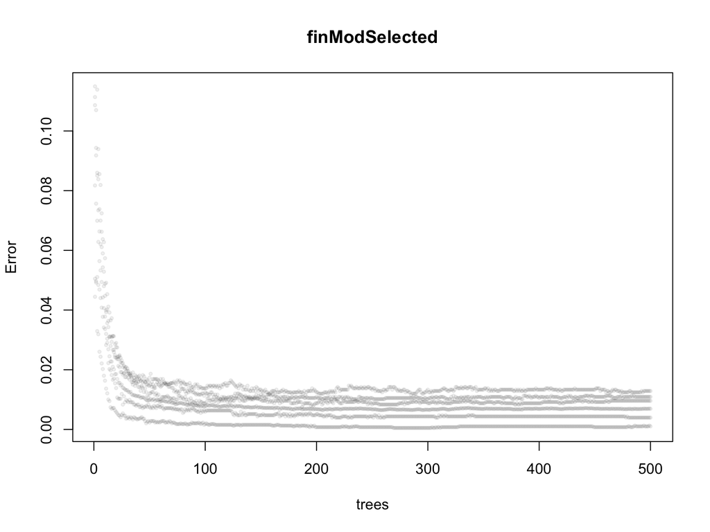

```r
finModSelected <- mod.rf3$finalModel
plot(finModSelected,"p",pch=19,cex=0.5,col="#00000010")
```

## Prediction in test set

The Random Forest model is applied to predict the “classe” variable in the testing set:

```r
set.seed(333)
pred.test <- predict(mod.rf3,testingAccFinal)
pred.test
```

```
##  [1] B A B A A E D B A A B C B A E E A B B B
## Levels: A B C D E
```

```r
summary(pred.test)
```

```
## A B C D E
## 7 8 1 1 3
```

## Reference

The data for this project come from this source: http://groupware.les.inf.puc-rio.br/har.

Velloso, E.; Bulling, A.; Gellersen, H.; Ugulino, W.; Fuks, H. Qualitative Activity Recognition of Weight Lifting Exercises. Proceedings of 4th International Conference in Cooperation with SIGCHI (Augmented Human ’13) . Stuttgart, Germany: ACM SIGCHI, 2013.

Read more: http://groupware.les.inf.puc-rio.br/har.#ixzz43OIKQ5Ua